# TinyUSB User Guide

## Introduction

TinyUSB is a cross-platform open-source USB Host/Device stack for embedded systems, designed to be memory-efficient, portable, and flexible.

The MSPM0 port of TinyUSB enables developers to easily implement various USB device and host classes on MSPM0 microcontrollers. This integration leverages the built-in USB peripheral of the MSPM0 devices.

Key features of the TinyUSB implementation for MSPM0 include:

- USB device and host class support
- Low memory footprint optimized for resource-constrained devices
- Simple API for quick implementation of USB functionality
- Integration with TI’s DriverLib for MSPM0
- Example applications demonstrating various USB use cases

## 1. USB Supported Classes

The MSPM0 port of TinyUSB implements a comprehensive suite of USB classes, enabling diverse application development. The current implementation supports:

### Device Mode

- **Communication Device Class (CDC)**: Virtual COM port functionality for serial communication
- **Human Interface Device (HID)**: Support for keyboards, mice, gamepads, and custom HID interfaces
- **Mass Storage Class (MSC)**: File storage and transfer capabilities
- **Billboard Class**: Enhanced device capability advertisement for USB-C applications
- **Audio Class**: Digital audio streaming functionality

### Host Mode

- **HID Host**: Support for connecting HID peripherals
- **MSC Host**: Capability to interface with USB storage devices
- **CDC Host**: Support for interfacing with CDC devices

## 2. USB Descriptor Tool

The USB Descriptor tool available in Sysconfig allows users to easily configure the stack and descriptors utilized during the enumeration process. As of this release, these classes are supported within the Descriptor tool.

### Basic USB Configuration

The USB Descriptor tool begins with providing users fundamental USB device parameters that defines how the device will identify itself to a host.

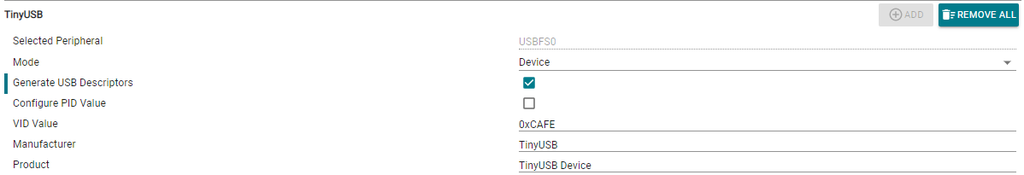

- **USB Mode**: Selection between Device mode or Host mode
- **Device Identification**: Vendor ID (VID) and Product ID (PID) assignment
- **Device Strings**: Manufacturer name, product name, and serial number

Each supported USB class in the SysConfig Descriptor Tool features dedicated configuration panels that enable precise customization of class behavior. These specialized interfaces allow developers to:

- Configure class-specific parameters tailored to functional requirements
- Allocate and size data buffers according to application needs
- Map class functions to appropriate USB endpoints
- Define instance-specific behaviors for multi-instance class implementations
- Set protocol-specific parameters that ensure compatibility with host systems

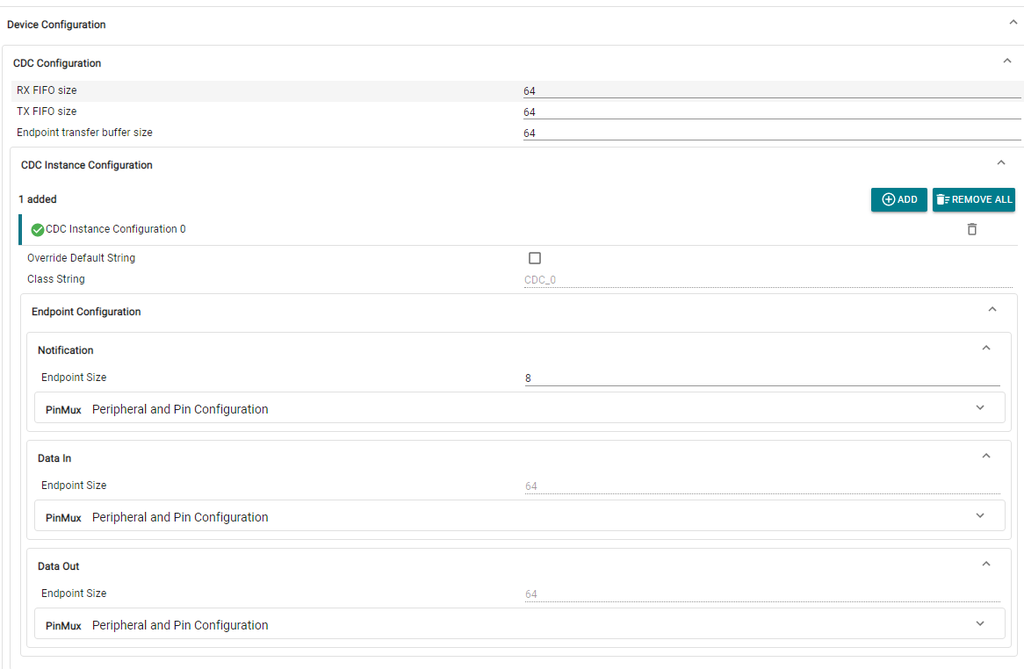

Beyond USB-specific settings, the USB Descriptor tool also provides configuration options to other peripherals that the TinyUSB stack utilizes:

- **GPIO Interfaces**: Configuration of buttons, LEDs, and other digital I/O used by USB applications
- **UART Controllers**: Setup of serial communication peripherals that may interact with USB CDC functionality
- **SysTick Timer**: Configuration of the system tick timer essential for USB timing operations and stack management

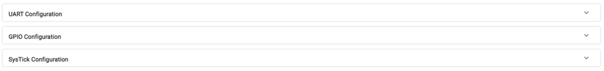

As of this release, these classes are supported within the USB Descriptor tool.

### Device Mode

- **Communication Device Class (CDC)**: Virtual COM port functionality for serial communication
- **Human Interface Device (HID)**: Support for keyboards, mice, gamepads, and custom HID interfaces
- **Mass Storage Class (MSC)**: File storage and transfer capabilities

### Host Mode

- **HID Host**: Support for connecting HID peripherals
- **MSC Host**: Capability to interface with USB storage devices
- **CDC Host**: Support for interfacing with CDC devices

Billboard and Audio device class support will be added to the descriptor tool in future releases.

## 3. TinyUSB Example Usage

This software library contains examples that demonstrate the USB peripheral in both host and device mode with different classes:

- **Device**:
  - **device_audio_test**: Shows device acting as microphone sending ramp signal to host
  - **device_billboard**: Demonstrates billboard class with different alternate modes
  - **device_billboard_cdc**: Demonstrates composite implementation of Billboard and CDC class
  - **device_cdc_acm_uart**: Bridge application between CDC and UART port
  - **device_cdc_dual_ports**: Creates two CDC ports that will echo characters, one being lower-case only while the other is upper-case only
  - **device_hid_cdc_composite_ti**: HID/CDC composite example demonstrating data from serial port being translated to HID commands
  - **device_hid_composite**: Demonstrates multiple HID interfaces in a single USB device
  - **device_hid_generic_inout**: HID device with bidirectional communication, allowing data exchange between host and device
  - **device_hid_keyboard_ti**: USB keyboard implementation that translates button input into keyboard report to host
  - **device_hid_mouse_ti**: USB mouse implementation that translates button input into mouse report to host
  - **device_msc_dual_lun**: MSC device presenting two logical storage units to the host from a single USB connection
  - **device_sd_card_bridge**: MSC implementation that provides host access to SD card connected to MSPM0
  - **device_uac2_headset**: Device functioning as headset with both playback and recording capabilities
  - **device_uac2_speaker_fb**: Speaker implementation with feedback for maintaining synchronization and audio quality
- **Host**:
  - **host_device_info**: Detects Connected devices, enumerates their capabilities, and displays device descriptor information
  - **host_msc_file_explorer**: File browser implementation for accessing and manipulating USB storage devices connected to the MSPM0

Each example contains source code which can be compiled and loaded onto a supported device as-is.

### 3.1 TinyUSB Examples Supported Hardware

- LP-MSPM0G5187 LaunchPad evaluation boards

## 4. TinyUSB Example Memory Usage

This section section shows the Flash and SRAM usage of various TinyUSB examples when compiled for MSPM0G5187 using these compilers:

- **TI ARM Clang**: v4.0.3
- **GCC**: GNU v9.2.1

**device_audio_test**

| Compiler | Optimization Level | Memory Usage |
| --- | --- | --- |
| GCC | -O0 No LTO | 32.7 KB (Flash) 1.33 KB (SRAM) |
| GCC | -O2 No LTO | 14.9 KB (Flash) 1.33 KB (SRAM) |
| Ticlang | -O0 No LTO | 28.8 KB (Flash) 1.45 KB (SRAM) |
| Ticlang | -O2 No LTO | 15.9 KB (Flash) 1.45 KB (SRAM) |

**device_cdc_dual_ports**

| Compiler | Optimization Level | Memory Usage |
| --- | --- | --- |
| GCC | -O0 No LTO | 27.9 KB (Flash) 1.3 KB (SRAM) |
| GCC | -O2 No LTO | 13.1 KB (Flash) 1.3 KB (SRAM) |
| Ticlang | -O0 No LTO | 23.5 KB (Flash) 1.3 KB (SRAM) |
| Ticlang | -O2 No LTO | 13.8 KB (Flash) 1.3 KB (SRAM) |

**device_billboard**

| Compiler | Optimization Level | Memory Usage |
| --- | --- | --- |
| GCC | -O0 No LTO | 21.3 KB (Flash) 0.99 KB (SRAM) |
| GCC | -O2 No LTO | 10.6 KB (Flash) 0.98 KB (SRAM) |
| Ticlang | -O0 No LTO | 17.9 KB (Flash) 0.94 KB (SRAM) |
| Ticlang | -O2 No LTO | 10.8 KB (Flash) 0.93 KB (SRAM) |

**device_msc_dual_lun**

| Compiler | Optimization Level | Memory Usage |
| --- | --- | --- |
| GCC | -O0 No LTO | 45.3 KB (Flash) 17.3 KB (SRAM) |
| GCC | -O2 No LTO | 30.1 KB (Flash) 17.4 KB (SRAM) |
| Ticlang | -O0 No LTO | 24.9 KB (Flash) 17.3 KB (SRAM) |
| Ticlang | -O2 No LTO | 14.3 KB (Flash) 17.3 KB (SRAM) |

**device_hid_cdc_composite_ti**

| Compiler | Optimization Level | Memory Usage |
| --- | --- | --- |
| GCC | -O0 No LTO | 32.3 KB (Flash) 1.6 KB (SRAM) |
| GCC | -O2 No LTO | 15.4 KB (Flash) 1.6 KB (SRAM) |
| Ticlang | -O0 No LTO | 27.8 KB (Flash) 1.6 KB (SRAM) |
| Ticlang | -O2 No LTO | 18.9 KB (Flash) 1.6 KB (SRAM) |

**host_msc_file_explorer**

| Compiler | Optimization Level | Memory Usage |
| --- | --- | --- |
| GCC | -O0 No LTO | 66.9 KB (Flash) 5.1 KB (SRAM) |
| GCC | -O2 No LTO | 41.6 KB (Flash) 5.1 KB (SRAM) |
| Ticlang | -O0 No LTO | 56.6 KB (Flash) 7.9 KB (SRAM) |
| Ticlang | -O2 No LTO | 47.4 KB (Flash) 7.9 KB (SRAM) |

## 5. TinyUSB Class Benchmarking

This section provides benchmarking that was performed using TI ARM Clang compiler 4.0.3.

**CDC-ACM Performance**

| Direction | Speed (MB/s) | MCU CPU Frequency (MHz) |
| --- | --- | --- |
| RX | 0.32 | 32 MHz |
| RX | 0.36 | 80 MHz |
| TX | 0.39 | 32 MHz |
| TX | 0.4 | 80 MHz |

Tests were conducted at two different CPU frequencies (32 MHz and 80 MHz) to evaluate how different frequencies will affect transfer speeds. In the respective test, the device_cdc_dual_ports example was modified to have a single CDC port and be either fully transmit or receive only.

**MSC Performance**

| Operation | Speed (MB/s) | MCU CPU Frequency (MHz) |
| --- | --- | --- |
| Read/Write | 0.36 | 32 MHz |
| Read/Write | 0.42 | 80 MHz |

Tests were conducted using DiskSpd utility, a storage performance benchmarking tool. The test evaluated the configuration in which the logical unit exists within SRAM.